# Module 3 Code Lab

Dipen Patel

# Introduction

Check the Module Overview for resources that may be helpful with this assignment. See the Code Lab Guidelines page for general directions on Code Lab assignments. See the Dataset Information page for background on the datasets used in the Code Lab assignments. See the Project Checkpoint Example Assignments for more details on these datasets and examples of working with the data.

## Goals

- Using several geoms effectively with categorical variables (representing groups in the data)
- Position and ordering options for bar charts
- How to make and interpret box plots and violin plots

## RStudio Tip

Code indentation getting wonky? There’s an option under the Code menu at the top of RStudio to re-indent code. You can apply this to a code chunk in R Markdown, a highlighted section, or an entire document. There’s also a keyboard shortcut (listed in the menu).

# Setup

```r
library(tidyverse)
library(lubridate)
library(janitor)
```

## Data files

This assignment uses the NMH dataset. **Download the NMH data folder from Canvas and put it as a subdirectory of your working directory.** It assumes that the data files are in a subdirectory of the working directory called NHM. Adjust your working directory if needed; do not change the file paths in the code below, or the instructor will not be able to knit your file. Dipen Patel

```r
path <- "D:/Toqeer_work/April/Data Visualization and storrytelling/week 3/NMH/NMH"
```

```r
stays <- read_csv(file.path(path,"stays.csv"))
```

```r
head(stays, n=5)
```

```
## # A tibble: 5 x 16
##   discharge_id patient_id stay_length   age gender num_glucose_tests max_glucose
##          <dbl>      <dbl>       <dbl> <dbl> <chr>              <dbl>       <dbl>
## 1     85007976    4032478       1.21     62 M                      4         221
## 2     85010139    1072283       4.13     64 F                     23         171
## 3     85010430    1022244       0.865    61 M                      7         179
## 4     85029060    2169051       5.09     72 F                     27         160
## 5     85069275    2844819       2.24     64 F                     14         369
## # i 9 more variables: min_glucose <dbl>, median_glucose <dbl>,
## #   mean_glucose <dbl>, admit_type <chr>, discharge_department <chr>,
## #   avg_tests_day <dbl>, insulin <lgl>, mean_creatinine <dbl>, mean_bun <dbl>
```

```r
col_names <- colnames(stays)


cat("Column names:\n")
```

```
## Column names:
```

```r
cat(col_names, sep = "\n")
```

```
## discharge_id
## patient_id
## stay_length
## age
## gender
## num_glucose_tests
## max_glucose
## min_glucose
## median_glucose
## mean_glucose
## admit_type
## discharge_department
## avg_tests_day
## insulin
## mean_creatinine
## mean_bun
```

```r
num_obs <- nrow(stays)
num_cols <- ncol(stays)

cat("Number of observations:", num_obs, "\n")
```

```
## Number of observations: 8203
```

```r
cat("Number of columns:", num_cols, "\n")
```

```
## Number of columns: 16
```

# Bar Chart Options

Bar charts are simple, but there are a number of different options regarding layout, especially when you include groups in the bar chart.

First, the basics. Let’s make a bar chart of gender:

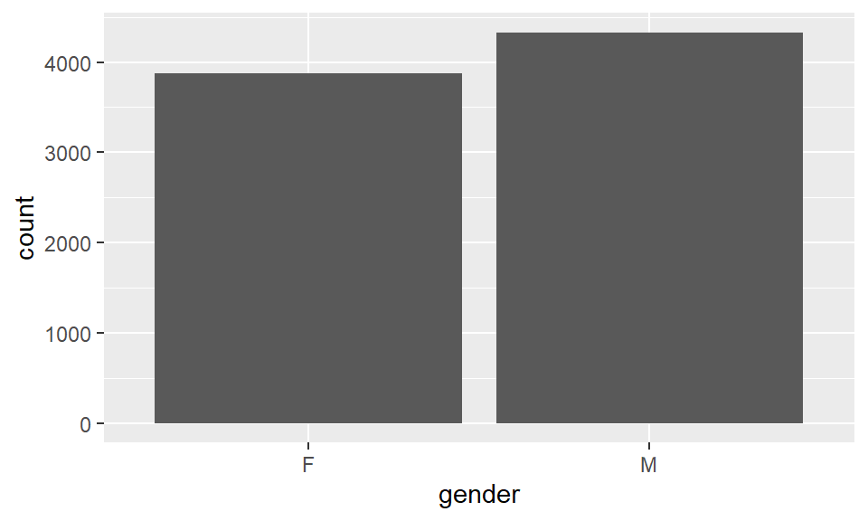

```r
ggplot(stays, aes(gender)) +
  geom_bar()
```

## Changing Labels

How do we change the bar labels? One way is to change the data:

```r
stays %>%
  mutate(gender = ifelse(gender == "F", "Female", "Male")) %>%
  ggplot(aes(gender)) +
  geom_bar()
```

[output not shown]

Another way is with the scale function

```r
ggplot(stays, aes(gender)) +
  geom_bar() +
  scale_x_discrete(labels=c("Female", "Male"))
```

[output not shown]

Be careful with this though, as it’s up to you to get the labels in the right order! To be more careful, use a named vector instead:

```r
ggplot(stays, aes(gender)) +
  geom_bar() +
  scale_x_discrete(labels=c("F"="Female", "M"="Male"))
```

[output not shown]

## Changing Order

The bar order can be set by modifying the data. The variable being mapped to the x axis is converted to a factor if it isn’t already. To override the default conversion, make it a factor yourself. The functions in the forcats package are particularly useful for helping to reorder categories.

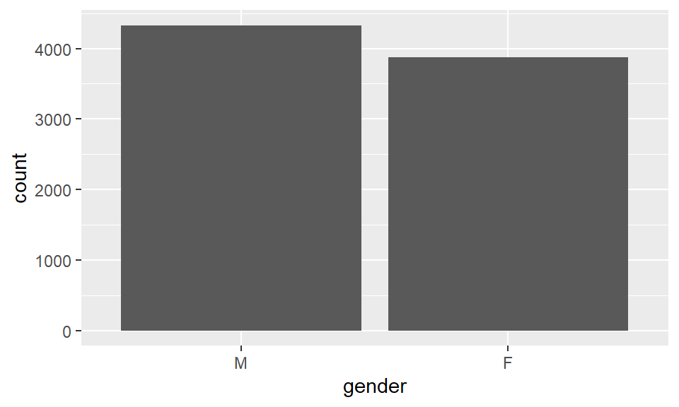

```r
stays %>%
  # order with most frequent category first
  mutate(gender = fct_infreq(gender)) %>%
  ggplot(aes(gender)) +
  geom_bar()
```

But you can also set factor levels manually: `mutate(gender = factor(gender, levels=c("M", "F")))`

## Bar Width

Bar width is relative to the size of the plot. If you save your plot in an image file (like .png) or output as part of R Markdown, the size of the overall plot will influence the size of the bars. Think of width as the percentage of the space allocated for each category that the bar actually takes up. The default is .9. You can supply values > 1, but that’s a bad idea because bars will overlap.

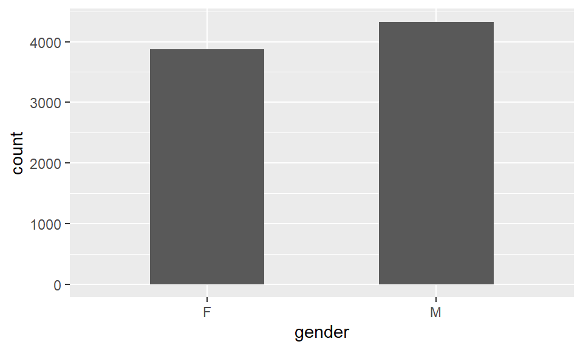

```r
ggplot(stays, aes(gender)) +
  geom_bar(width=.5)
```

## Groups

Now, how to do include groups in the bar chart? Put another way, how do you make a bar chart with two categorical variables? One still needs to be mapped to the x aesthetic, the other needs to be mapped to something else – fill is the most common choice.

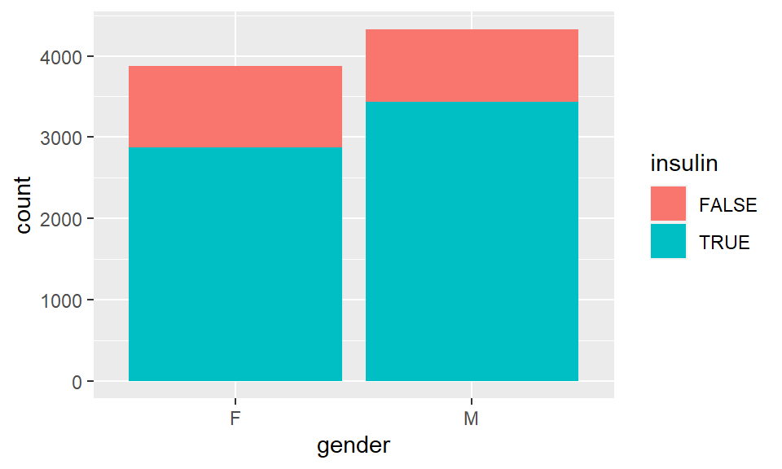

```r
ggplot(stays, aes(x=gender, fill=insulin)) +
  geom_bar()
```

You automatically get the legend.

## Bar Position

With groups, there are three different ways to represent the groups with the bars. The default, above, is “stacked”: `position = "stacked"`.

There is also side-by-side, which is “dodge”:

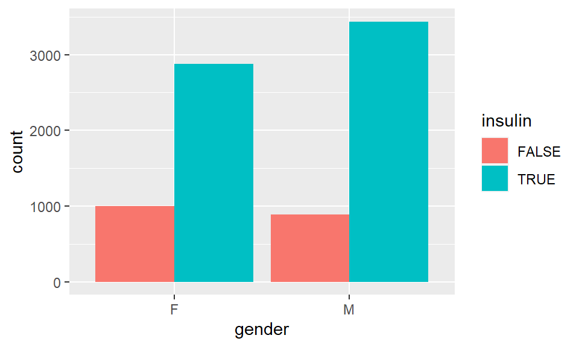

```r
ggplot(stays, aes(x=gender, fill=insulin)) +
  geom_bar(position="dodge")
```

And stacked as proportions instead of counts - “fill”:

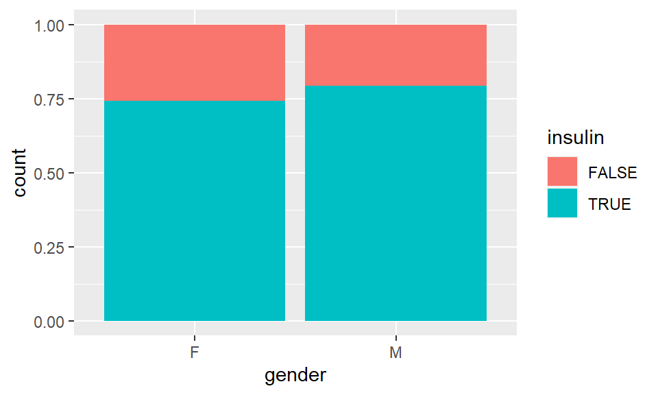

```r
ggplot(stays, aes(x=gender, fill=insulin)) +
  geom_bar(position="fill")
```

This arrangement makes it easy to see that a higher proportion of male patients are taking insulin than of female patients because you can easily compare the break point between the two plots.

The y-axis still says “count” although this is inaccurate, as it’s a proportion now. You should update this label manually.

With the “dodge” position: what if we wanted to group by insulin instead of by gender? Then we change which variable is matched to which aesthetic:

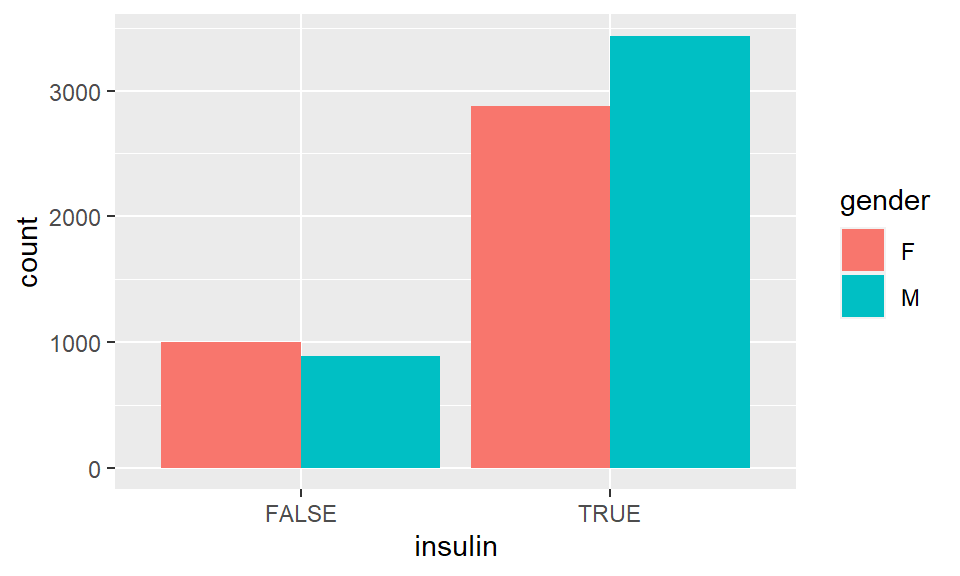

```r
ggplot(stays, aes(fill=gender, x=insulin)) +
  geom_bar(position="dodge")
```

Which grouping and positioning you want depends on what comparisons you want to emphasize. Here, the main message is that there are fewer patients not taking insulin than ones who are. The gender comparison is within each of the two insulin categories – for a given group, what is the gender split.

For the prior “dodged” plot above, you still get the overall message that there are more insulin-takers (the teal bars are much bigger), but for gender, I don’t get a clear takeaway. The message is more that: *for both genders*, there are more insulin takers than not.

It’s a relatively subtle difference. We’ll spend more time on how grouping affects perception later in the course.

## Bar Chart with Known Values

Above, we’ve been counting observations in the data – “count” of some sort has been on the y-axis. What if we want to use a bar chart to show some quantity we already have computed? Then instead of letting the stat function compute the values for the y-axis for us, we need to supply the y values.

Use a bar chart to represent the average glucose test results (average of mean_glucose, so average of averages) for those taking insulin vs. not.

```r
stays %>%
  group_by(insulin) %>%
  summarize(avg_glucose = mean(mean_glucose))
```

```
## # A tibble: 2 x 2
##   insulin avg_glucose
##   <lgl>         <dbl>
## 1 FALSE          125.
## 2 TRUE           179.
```

Since the default stat function wants to count our data and compute y, we need to specify to use a different stat function: “identity” (which means don’t change the data)

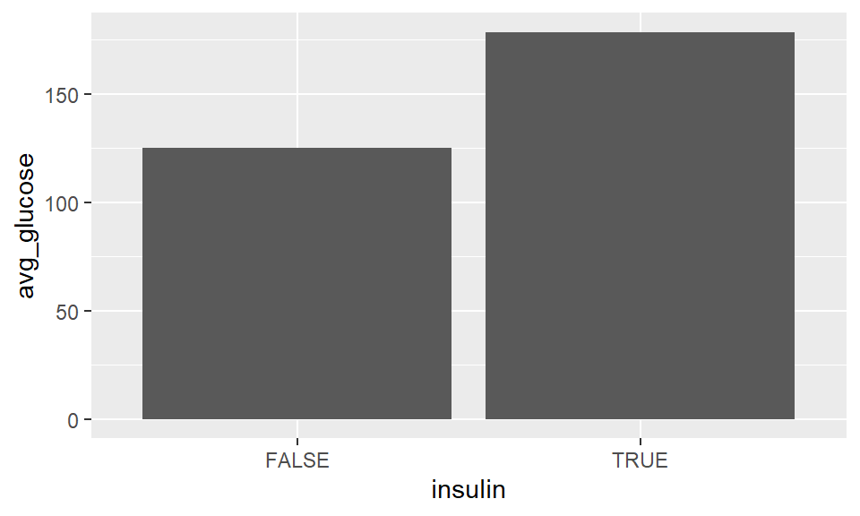

```r
stays %>%
  group_by(insulin) %>%
  summarize(avg_glucose = mean(mean_glucose)) %>%
  # The lines above compute the per-group averages as in the chunk above
  # then send this result to ggplot to plot
  ggplot(aes(x=insulin, y=avg_glucose)) +
  geom_bar(stat="identity")
```

Alternatively, we can use `geom_col()` which has “identity” as the default stat function:

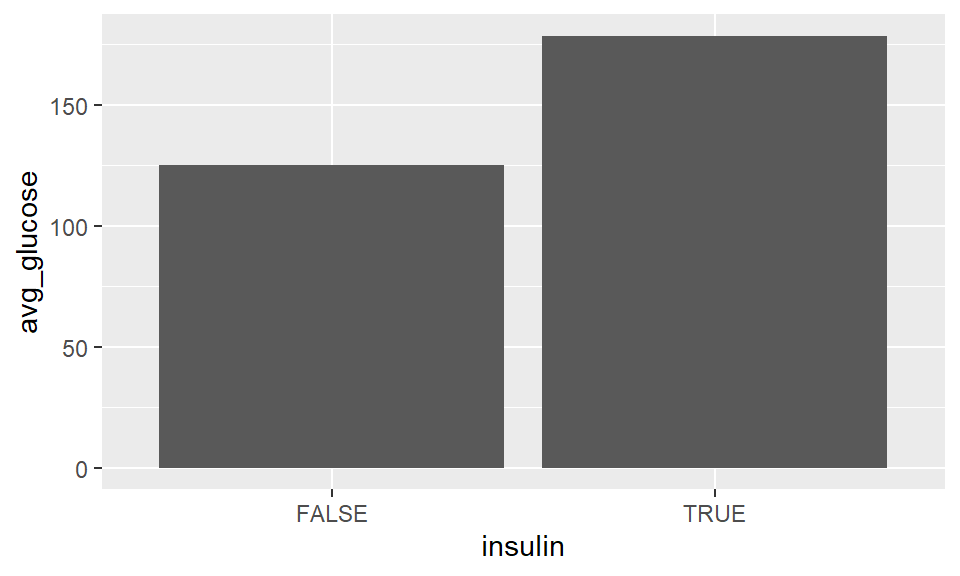

```r
stays %>%
  group_by(insulin) %>%
  summarize(avg_glucose = mean(mean_glucose)) %>%
  ggplot(aes(x=insulin, y=avg_glucose)) +
  geom_col()
```

Or even change the “stat” used by ggplot directly:

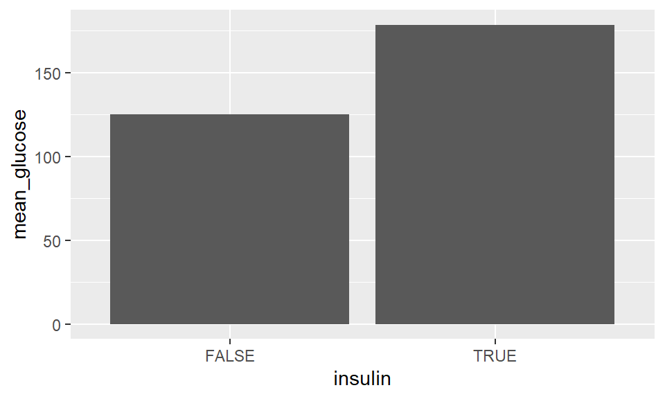

```r
stays %>%
  ggplot(aes(x=insulin, y=mean_glucose)) +
  geom_bar(stat="summary", fun=mean)
```

## Bar Chart with Proportions/Percentages

What if you want to show proportions or percentages on the y-axis instead of counts? This is a special case of the above. You could compute these beforehand. But you can also access the “counts” computed by `stat_count()` (what `geom_bar()` uses).

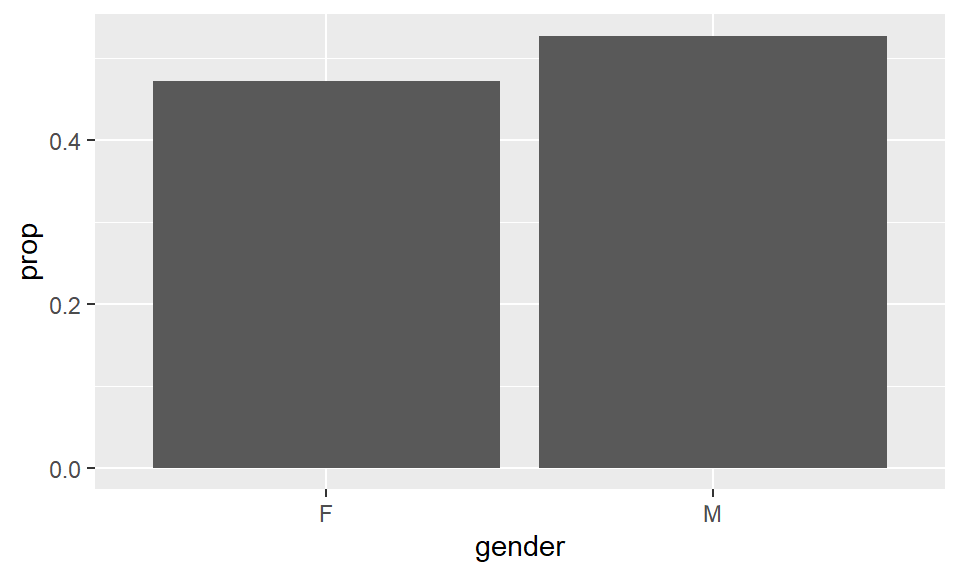

```r
ggplot(stays) +
  geom_bar(aes(x=gender, y=after_stat(prop), group=1))
```

Note that the syntax for `after_stat(prop)` used to be `..prop..`, which you might see in older examples or documentation. `after_stat(prop) gives you **groupwise** proportions. So we need to specify a "group" (hence`group=1`. Without it, we get:

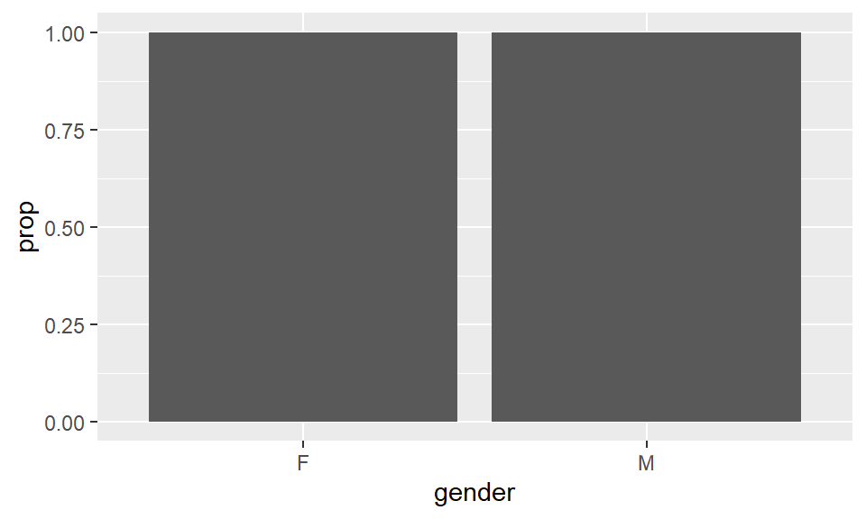

```r
ggplot(stays) +
  geom_bar(aes(x=gender, y=after_stat(prop)))
```

Because each bar is it’s own group. We don’t want this.

To convert the y-axis to a percentage format:

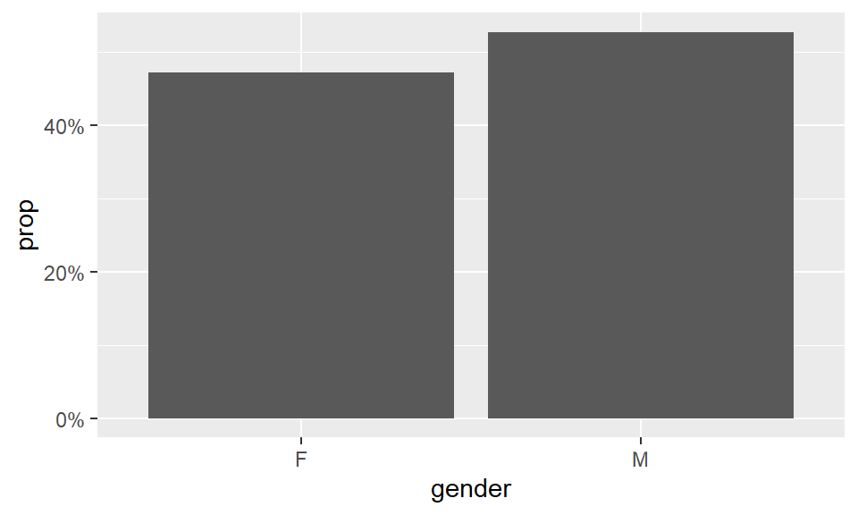

```r
ggplot(stays) +
  geom_bar(aes(x=gender, y=after_stat(prop), group=1)) +
  scale_y_continuous(labels=scales::label_percent())
```

# EXERCISE 1

Make a new variable in the `stays` data frame that indicates whether the patient stayed more than a week (the `stay_length` variable, which is computed in days, will help you here).

Then make a bar plot that will help you determine whether older patients are more likely to stay longer than a week.

Here’s some code that turns age into a categorical variable, which can be useful for looking at age effects.

```r
stays <- stays %>%
  mutate(age_decade = case_when(age < 20 ~ "Teens",
                                age < 30 ~ "20s",
                                age < 40 ~ "30s",
                                age < 50 ~ "40s",
                                age < 60 ~ "50s",
                                age < 70 ~ "60s",
                                age < 80 ~ "70s",
                                TRUE ~ "80s"),
         age_decade = factor(age_decade, levels=c("Teens", "20s", "30s", "40s", "50s", "60s", "70s", "80s")))
```

Note: There are a few different ways you could go about this (including options that don’t use the `age_decade` variable created above), so there’s more than one “right” answer.

```r
stays <- stays %>%
  mutate(stay_longer_week = ifelse(stay_length > 7, "yes", "no"))
```

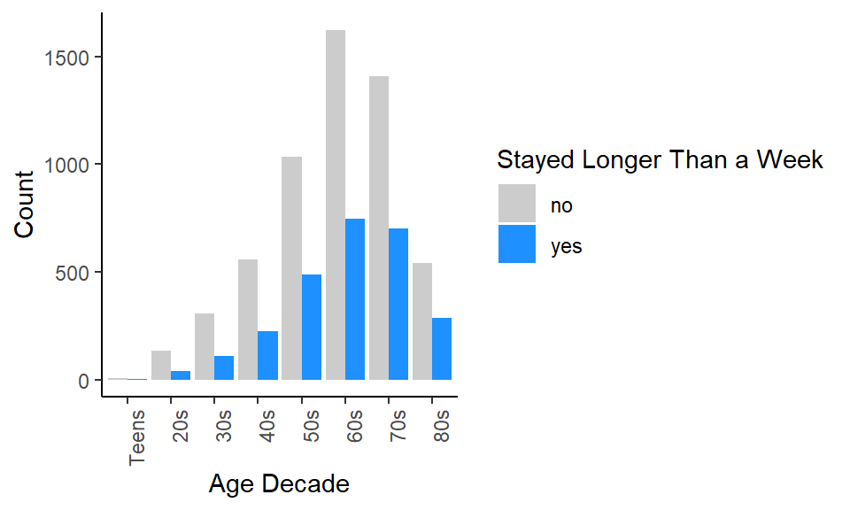

```r
ggplot(stays, aes(x=age_decade, fill=stay_longer_week)) +
  geom_bar(position="dodge") +
  scale_fill_manual(values=c("no"="gray80", "yes"="dodgerblue")) +
  labs(x="Age Decade", y="Count", fill="Stayed Longer Than a Week") +
  theme_classic() +
  theme(axis.text.x = element_text(angle = 90, hjust = 1))
```

# Box and Violin Plots

Box and violin plots provide an alternative to histograms for summarizing the distribution of continuous data. While you can make each of these plots for all of your observations together, they are most useful and effective for comparing the distribution of a variable by groups in your data (a categorical variable).

## Box Plot

Box plots show multiple summary statistics of a variable. Whether you map the variable of interest to x or y determines the orientation of the plot.

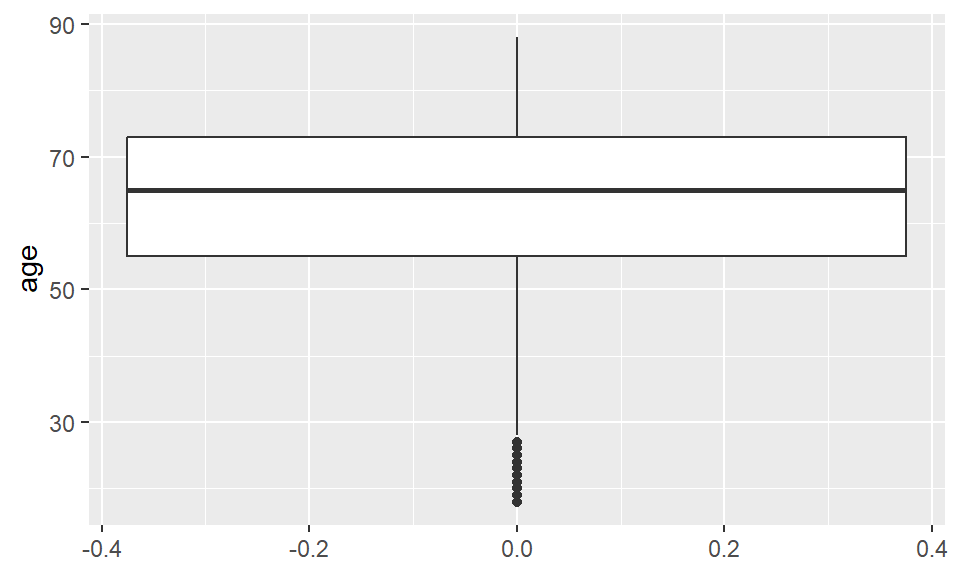

```r
ggplot(stays, aes(y=age)) +
  geom_boxplot()
```

This graph shows the median age which is 65 or 66 and the age group who have to stays more is the 55 to 72 because the box lies in this age group.

This is fine, but there are plots that, in most cases, are more effective visualizations of a distribution. Box plots do let us see many distributions at once, if we have a categorical variable to group our data:

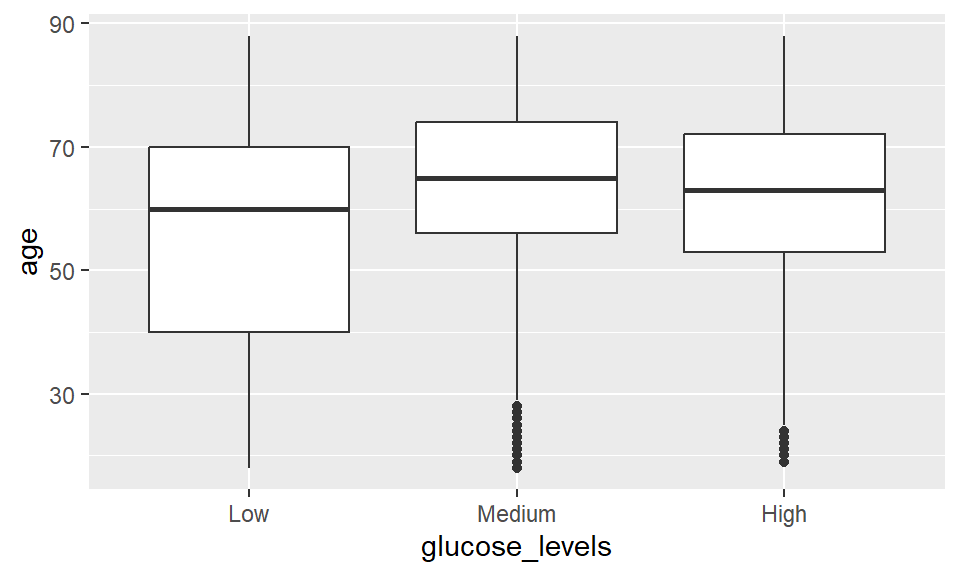

```r
# create categories that we want to examine distributions across
stays <- stays %>%
  mutate(glucose_levels = case_when(mean_glucose < 100 ~ "Low",
                           mean_glucose < 200 ~ "Medium",
                           TRUE ~ "High"),
         glucose_levels = factor(glucose_levels, levels=c("Low", "Medium", "High")))

stays %>%
  ggplot(aes(x=glucose_levels, y=age)) +
  geom_boxplot()
```

Here we can see that those with low glucose levels tend to be a little younger. More specifically, there’s a longer “left” (or lower) tail on age for those in the “Low” glucose category than in the others (the box extends further to younger ages).

Flip this around:

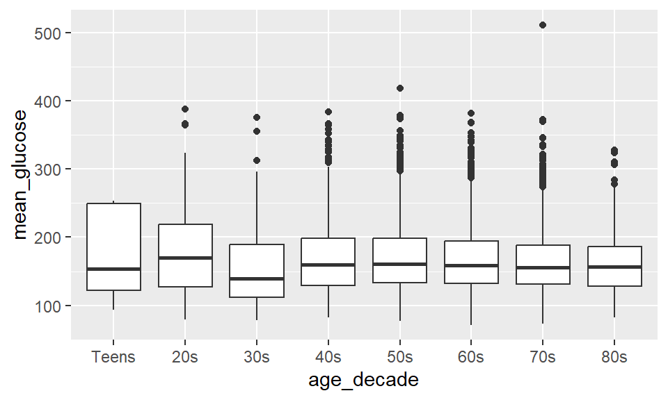

```r
stays %>%
  # age_decade was created above
  ggplot(aes(x=age_decade, y=mean_glucose)) +
  geom_boxplot()
```

Interestingly, for the youngest patients, of which there are few, there’s a longer tail of higher glucose values.

# EXERCISE 2

Look at the help/documentation page for `geom_boxplot()` (or other resources):

- What value is shown by the middle bar of the boxplot?

The median of the data is shown by the middle bar in a boxplot.

- What is IQR?

The middle 50% of the data is known as the interquartile range, or IQR. The 75th percentile (Q3) and the 25th percentile (Q1) of the data are used to calculate it.

- How does it determine what counts as an outlier?

Any observation outside of the range Q1 - 1.5IQR to Q3 + 1.5IQR is regarded as an outlier in a typical boxplot and is represented as a point outside the whiskers. However, the definition of an outlier can be modified based on the situation and the analysis’s goal.

# EXERCISE 3

Make a boxplot of `max_glucose`, grouping by both `age_decade` and `insulin`. Choose one of the grouping variables to map to x, and one to map to fill, as with a bar plot.

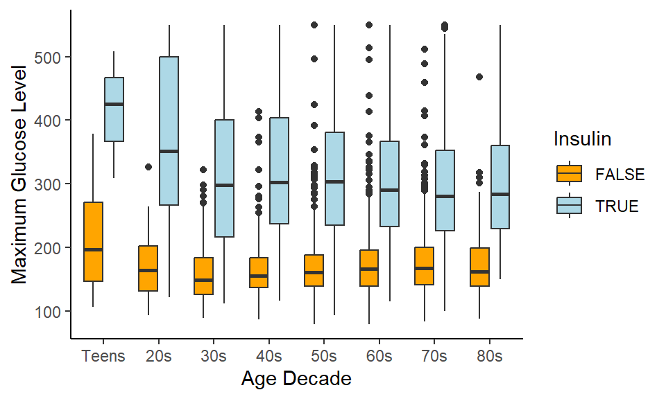

```r
# First, define a vector of colors
my_colors <- c("orange", "light blue", "green")

# Then, use the scale_fill_manual function to set the fill colors
stays %>%
  ggplot(aes(x=age_decade, y=max_glucose, fill=insulin)) +
  geom_boxplot() +
  scale_fill_manual(values=my_colors) +
  labs(x="Age Decade", y="Maximum Glucose Level", fill="Insulin") +
  theme_classic()
```

Unlike `geom_boxplot()`, `geom_violin()` expects there to be groups.

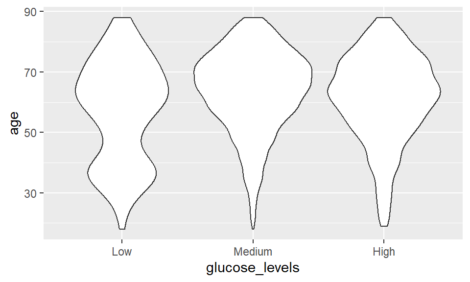

```r
stays %>%
  ggplot(aes(x=glucose_levels, y=age)) +
  geom_violin()
```

What is this showing? It’s a density plot, turned vertical, with the width centered instead of running along an axis. The width corresponds to how many observations are at each y value, and then these values are smoothed.

Compared to the box plot above, we can see a bit more detail of the distributions here. For those with “Low” glucose levels, we can see there’s a bit of a bimodal (or at least two peaks) distribution of ages. The other glucose categories have smoother distributions across age ranges. It’s harder though to compare means or medians, since they aren’t shown explicitly on the plot (you can add them).

Group by age categories:

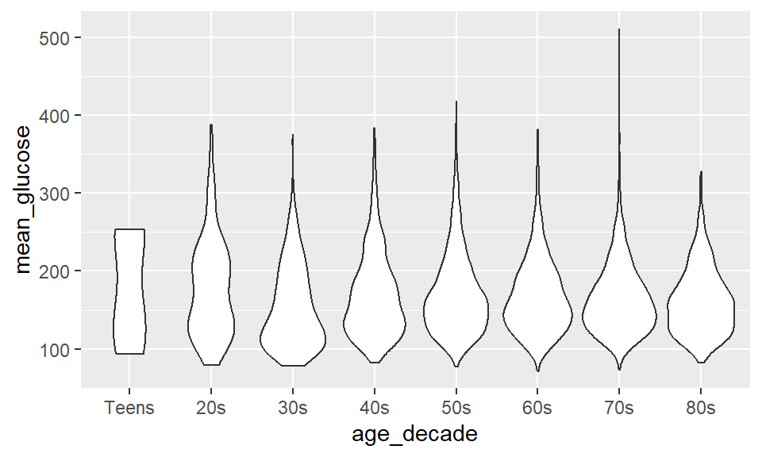

```r
stays %>%
  ggplot(aes(x=age_decade, y=mean_glucose)) +
  geom_violin()
```

There are only a handful of patients in their teens, but you can’t tell that here. The default is for the area of each violin plot to be the same. You can change this though:

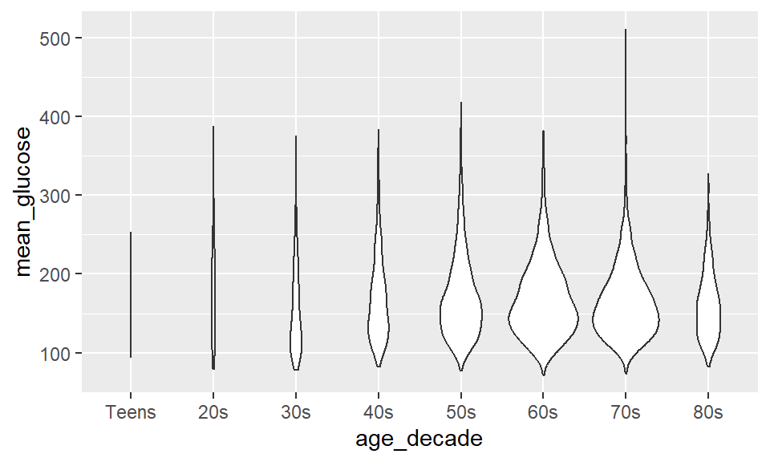

```r
stays %>%
  ggplot(aes(x=age_decade, y=mean_glucose)) +
  geom_violin(scale="count")
```

It makes it harder to see the distribution for the smaller groups, but easier to see where the bulk of the data is.

# EXERCISE 4

Look up the help/documentation for `geom_violin()` or use other resources to figure out how to mark the median value, 25th percentile, and 75th percentile for each group on the violin plot below.

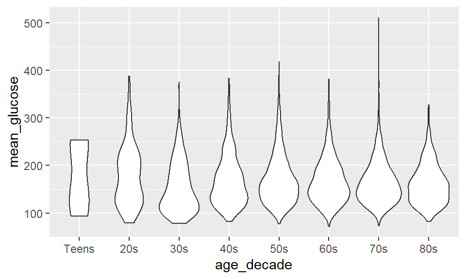

```r
stays %>%
  ggplot(aes(x=age_decade, y=mean_glucose)) +
  geom_violin()
```

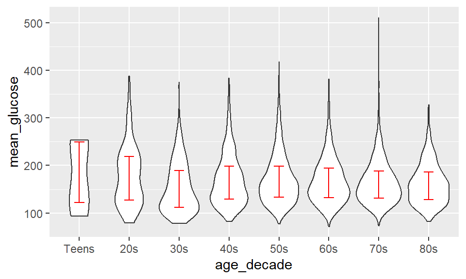

```r
stays %>%
  ggplot(aes(x=age_decade, y=mean_glucose)) +
  geom_violin() +
  stat_summary(fun.data = function(x) {
    return(data.frame(y=median(x), ymin=quantile(x, 0.25), ymax=quantile(x, 0.75)))
  }, geom = "errorbar", width=0.2, color="red")
```

In the Teens plot the 25th percentile is mean_glucose is 120 and on the other hand 75th percentile is 250.which is clearly shown in this graph

## Combining Geoms

We can use more than one geom on the same plot. While this can quickly result in plots that are overly complicated, sometimes it’s useful:

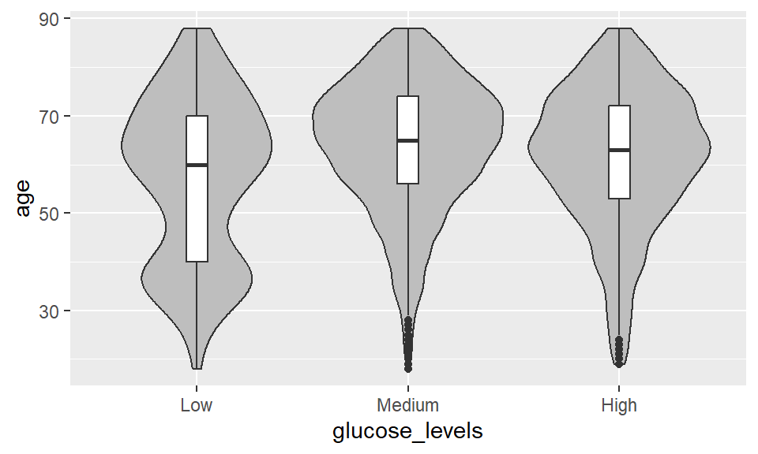

```r
stays %>%
  ggplot(aes(x=glucose_levels, y=age)) +
  geom_violin(fill="gray") +
  geom_boxplot(width=.1) +
  theme(legend.position = "none")
```

A plot like this might be appropriate for a scientific audience, but it would be too complicated for executives, patients, or other audiences. Hopefully it helps you see the correspondence between these two plot types though.